# MB5370 Workshop 2 Keystone Exercise

Caitlin Buckle

2026-07-28

## Introduction

The Premise: You have inherited a project from a former PhD student who was studying the relationship between water quality and predatory fish assemblages along the Ross River Estuary gradient. Unfortunately, their data management was entirely manual, and the files are a disaster.

They left you with four separate datasets: estuary_catch_log.xlsx: Handwritten field counts of fish species (using common names), spread across multiple spreadsheet tabs. estuary_metadata.csv: The spatial coordinates and estuary zones for each site. estuary_sonde_data.csv: High-frequency water quality sensor readings. species_dictionary.csv: A taxonomic lookup table linking local common names to their accepted scientific names.

Your mission is to write a single, reproducible R script (or .qmd) that ingests this mess, cleans it, joins it into a single master dataset, and produces a publication-ready visualisation of the estuary’s ecology.

Note: the datasets are now available in the class repository

## PHASE ONE: Ingestion and Decontamination

Load the four datasets and think about how to clean and wrangle them individually

```r
#Load packages
library(tidyverse) #includes dplyr, ggplot2, lubridate
library(readxl) #for reading excel files
```

#### Load files into R

```r
#Load .csv files using read_csv (files are stored in workshop2 folder inside data folder)
metadata<- read_csv("../data/workshop2/estuary_metadata.csv")
sonde_data<- read_csv("../data/workshop2/estuary_sonde_data.csv")
species_dict<-read.csv("../data/workshop2/species_dictionary.csv")

catch_log_1<- read_excel("../data/workshop2/estuary_catch_log.xlsx", sheet = "Lower_ross")
catch_log_2<- read_excel("../data/workshop2/estuary_catch_log.xlsx", sheet = "Mid_Ross ")
catch_log_3<- read_excel("../data/workshop2/estuary_catch_log.xlsx", sheet = "ROSS MOUTH")
catch_log_4<- read_excel("../data/workshop2/estuary_catch_log.xlsx", sheet = "Upper Ross")
catch_log<-bind_rows(catch_log_1, catch_log_2, catch_log_3, catch_log_4) #individually loaded in each sheet from excel file, so had to bind them into one data frame --> catch_log
```

### Standardise all site and species columns to lowercase with underscores

```r
clean_catch<-catch_log%>%
  mutate(
    site_clean=str_to_lower(site), #convert to lowercase
    site_clean=str_trim(site_clean), #remove whitespace
    site_clean=str_replace_all(site_clean,pattern=" ",replacement="_") #replace with underscores where needed
  )%>%
  mutate(
    species_clean=str_to_lower(species), #convert to lowercase
    species_clean=str_trim(species_clean), #remove whitespace
    species_clean=str_replace_all(species_clean,pattern=" ",replacement="_") #replace spaces between species names with underscores
  )
print(clean_catch) #much better!
```

```
## # A tibble: 427 × 6
##    site       date                species       count site_clean species_clean
##    <chr>      <dttm>              <chr>         <dbl> <chr>      <chr>
##  1 Lower_ross 2026-05-01 00:00:00 barramundi        6 lower_ross barramundi
##  2 Lower_ross 2026-05-01 00:00:00 MANGROVE JACK     3 lower_ross mangrove_jack
##  3 Lower_ross 2026-05-01 00:00:00 bream             4 lower_ross bream
##  4 Lower_ross 2026-05-01 00:00:00 flathead          2 lower_ross flathead
##  5 Lower_ross 2026-05-02 00:00:00 barramundi        1 lower_ross barramundi
##  6 Lower_ross 2026-05-02 00:00:00 MANGROVE JACK     1 lower_ross mangrove_jack
##  7 Lower_ross 2026-05-02 00:00:00 bream             3 lower_ross bream
##  8 Lower_ross 2026-05-02 00:00:00 flathead          3 lower_ross flathead
##  9 Lower_ross 2026-05-03 00:00:00 MANGROVE JACK     2 lower_ross mangrove_jack
## 10 Lower_ross 2026-05-03 00:00:00 flathead          3 lower_ross flathead
## # ℹ 417 more rows
```

```r
clean_metadata<-metadata%>%
  mutate(
    site_clean=str_to_lower(site_name),
    site_clean=str_trim(site_clean),
    site_clean=str_replace_all(site_clean,pattern=" ",replacement="_")
  )
print(clean_metadata)
```

```
## # A tibble: 4 × 5
##   site_name    lat   lon zone       site_clean
##   <chr>      <dbl> <dbl> <chr>      <chr>
## 1 Upper_Ross -19.3  147. Upstream   upper_ross
## 2 mid_ross   -19.3  147. Middle     mid_ross
## 3 LOWER ROSS -19.3  147. Downstream lower_ross
## 4 ross_mouth -19.2  147. Marine     ross_mouth
```

### Fix temporal parsing in sonde data

```r
clean_sonde<-sonde_data%>%
  mutate(
     true_time=dmy_hm(timestamp) #telling mutate that our preferred time structure is day-month-year-hour-minute
  )
print(clean_sonde) #new column called true_time with format of day-month-year-hour-minute
```

```
## # A tibble: 11,520 × 6
##    site       timestamp       temperature salinity turbidity true_time
##    <chr>      <chr>                 <dbl>    <dbl>     <dbl> <dttm>
##  1 upper_ross 01/05/2026 00:…        23.7     4.05      6.49 2026-05-01 00:00:00
##  2 mid_ross   01/05/2026 00:…        24.1    15.7      49.2  2026-05-01 00:00:00
##  3 lower_ross 01/05/2026 00:…        24.2    28.9      48.1  2026-05-01 00:00:00
##  4 ross_mouth 01/05/2026 00:…        24.6    33.9      49.8  2026-05-01 00:00:00
##  5 upper_ross 01/05/2026 00:…        26.1     3.96     25.2  2026-05-01 00:15:00
##  6 mid_ross   01/05/2026 00:…        24.6    12.1      34.8  2026-05-01 00:15:00
##  7 lower_ross 01/05/2026 00:…        22.9    30.9      33.9  2026-05-01 00:15:00
##  8 ross_mouth 01/05/2026 00:…        20.6    33.9      27.4  2026-05-01 00:15:00
##  9 upper_ross 01/05/2026 00:…        24.9     4.32     13.0  2026-05-01 00:30:00
## 10 mid_ross   01/05/2026 00:…        24.3    17.4      31.9  2026-05-01 00:30:00
## # ℹ 11,510 more rows
```

### Remove -999 values from turbidity sensors

```r
# Convert the -999 error codes to true NA values
cleaned_sonde<- clean_sonde%>%
  mutate(turbidity= na_if(turbidity, -999))

print(cleaned_sonde)
```

```
## # A tibble: 11,520 × 6
##    site       timestamp       temperature salinity turbidity true_time
##    <chr>      <chr>                 <dbl>    <dbl>     <dbl> <dttm>
##  1 upper_ross 01/05/2026 00:…        23.7     4.05      6.49 2026-05-01 00:00:00
##  2 mid_ross   01/05/2026 00:…        24.1    15.7      49.2  2026-05-01 00:00:00
##  3 lower_ross 01/05/2026 00:…        24.2    28.9      48.1  2026-05-01 00:00:00
##  4 ross_mouth 01/05/2026 00:…        24.6    33.9      49.8  2026-05-01 00:00:00
##  5 upper_ross 01/05/2026 00:…        26.1     3.96     25.2  2026-05-01 00:15:00
##  6 mid_ross   01/05/2026 00:…        24.6    12.1      34.8  2026-05-01 00:15:00
##  7 lower_ross 01/05/2026 00:…        22.9    30.9      33.9  2026-05-01 00:15:00
##  8 ross_mouth 01/05/2026 00:…        20.6    33.9      27.4  2026-05-01 00:15:00
##  9 upper_ross 01/05/2026 00:…        24.9     4.32     13.0  2026-05-01 00:30:00
## 10 mid_ross   01/05/2026 00:…        24.3    17.4      31.9  2026-05-01 00:30:00
## # ℹ 11,510 more rows
```

```r
summary(cleaned_sonde) #all -999 changed into NA, now have 567 NA's in the data set
```

```
##      site            timestamp          temperature       salinity
##  Length:11520       Length:11520       Min.   :18.14   Min.   :-2.224
##  Class :character   Class :character   1st Qu.:23.00   1st Qu.: 8.268
##  Mode  :character   Mode  :character   Median :24.01   Median :22.255
##                                        Mean   :24.00   Mean   :20.462
##                                        3rd Qu.:24.98   3rd Qu.:32.500
##                                        Max.   :29.61   Max.   :37.773
##
##    turbidity        true_time
##  Min.   : 1.001   Min.   :2026-05-01 00:00:00
##  1st Qu.:13.474   1st Qu.:2026-05-08 11:56:15
##  Median :25.508   Median :2026-05-15 23:52:30
##  Mean   :25.554   Mean   :2026-05-15 23:52:30
##  3rd Qu.:37.745   3rd Qu.:2026-05-23 11:48:45
##  Max.   :49.998   Max.   :2026-05-30 23:45:00
##  NA's   :567
```

## PHASE TWO: THE RELATIONAL ARCHITECTURE

Bringing the data together into a cohesive formula

```r
#using floor_date() inside labridate to group temperature values for each site on each day
sonde_daily<-cleaned_sonde%>%
  mutate(
    day=floor_date(true_time,unit="day") #rounds the timestamps down to just the date
    )%>%
  group_by(site,day)%>% #group by the site and your new daily date column
  summarise(
    mean_temp=mean(temperature,na.rm=TRUE),
    mean_salinity=mean(salinity,na.rm=TRUE),
    .groups="drop"
  )
print(sonde_daily) #tibble has 120 rows and four variables, grouped by day and then a column for mean_temp and mean_salinity
```

```
## # A tibble: 120 × 4
##    site       day                 mean_temp mean_salinity
##    <chr>      <dttm>                  <dbl>         <dbl>
##  1 lower_ross 2026-05-01 00:00:00      23.8          28.4
##  2 lower_ross 2026-05-02 00:00:00      24.0          27.7
##  3 lower_ross 2026-05-03 00:00:00      24.2          28.1
##  4 lower_ross 2026-05-04 00:00:00      24.0          28.2
##  5 lower_ross 2026-05-05 00:00:00      23.9          27.6
##  6 lower_ross 2026-05-06 00:00:00      24.0          28.2
##  7 lower_ross 2026-05-07 00:00:00      24.0          27.6
##  8 lower_ross 2026-05-08 00:00:00      24.0          28.0
##  9 lower_ross 2026-05-09 00:00:00      24.0          27.8
## 10 lower_ross 2026-05-10 00:00:00      23.9          28.1
## # ℹ 110 more rows
```

### Taxonomic translation

Need to merge species_dictionary into your catch data, replacing the common names with accurate scientific taxonomy.

```r
cc_scientific<-clean_catch %>%
  left_join(species_dict,by=join_by(species_clean==common_name)) #joining species_dict to clean_catch, have specified that species_clean in clean_watch is equal to common_name in species_dict


print(cc_scientific)
```

```
## # A tibble: 427 × 7
##    site       date                species       count site_clean species_clean
##    <chr>      <dttm>              <chr>         <dbl> <chr>      <chr>
##  1 Lower_ross 2026-05-01 00:00:00 barramundi        6 lower_ross barramundi
##  2 Lower_ross 2026-05-01 00:00:00 MANGROVE JACK     3 lower_ross mangrove_jack
##  3 Lower_ross 2026-05-01 00:00:00 bream             4 lower_ross bream
##  4 Lower_ross 2026-05-01 00:00:00 flathead          2 lower_ross flathead
##  5 Lower_ross 2026-05-02 00:00:00 barramundi        1 lower_ross barramundi
##  6 Lower_ross 2026-05-02 00:00:00 MANGROVE JACK     1 lower_ross mangrove_jack
##  7 Lower_ross 2026-05-02 00:00:00 bream             3 lower_ross bream
##  8 Lower_ross 2026-05-02 00:00:00 flathead          3 lower_ross flathead
##  9 Lower_ross 2026-05-03 00:00:00 MANGROVE JACK     2 lower_ross mangrove_jack
## 10 Lower_ross 2026-05-03 00:00:00 flathead          3 lower_ross flathead
## # ℹ 417 more rows
## # ℹ 1 more variable: scientific_name <chr>
```

### Merge translated catch date, spatial metadata and your daily water quality summaries into a single master data frame.

Translated catch data = cc_scientific Spatial metadata = clean_metadata Daily water quality summaries = sonde_daily

```r
master <- cc_scientific %>%
  left_join(clean_metadata, by = join_by(site_clean == site_clean)) %>%  #join clean_metadata to cc_scientific
  mutate(date_fixed = ymd(date)) %>% #fix date column in new data frame (specify it is ymd)
  left_join(sonde_daily, by = join_by(site_clean == site, date_fixed == day)) #join sonde_daily to other joins

print(master)
```

```
## # A tibble: 427 × 14
##    site       date                species       count site_clean species_clean
##    <chr>      <dttm>              <chr>         <dbl> <chr>      <chr>
##  1 Lower_ross 2026-05-01 00:00:00 barramundi        6 lower_ross barramundi
##  2 Lower_ross 2026-05-01 00:00:00 MANGROVE JACK     3 lower_ross mangrove_jack
##  3 Lower_ross 2026-05-01 00:00:00 bream             4 lower_ross bream
##  4 Lower_ross 2026-05-01 00:00:00 flathead          2 lower_ross flathead
##  5 Lower_ross 2026-05-02 00:00:00 barramundi        1 lower_ross barramundi
##  6 Lower_ross 2026-05-02 00:00:00 MANGROVE JACK     1 lower_ross mangrove_jack
##  7 Lower_ross 2026-05-02 00:00:00 bream             3 lower_ross bream
##  8 Lower_ross 2026-05-02 00:00:00 flathead          3 lower_ross flathead
##  9 Lower_ross 2026-05-03 00:00:00 MANGROVE JACK     2 lower_ross mangrove_jack
## 10 Lower_ross 2026-05-03 00:00:00 flathead          3 lower_ross flathead
## # ℹ 417 more rows
## # ℹ 8 more variables: scientific_name <chr>, site_name <chr>, lat <dbl>,
## #   lon <dbl>, zone <chr>, date_fixed <dttm>, mean_temp <dbl>,
## #   mean_salinity <dbl>
```

```r
master_df <- master %>%
  select(-c(site, site_name, species, date_fixed)) #remove unnecessary columns

print(master_df)
```

```
## # A tibble: 427 × 10
##    date                count site_clean species_clean scientific_name        lat
##    <dttm>              <dbl> <chr>      <chr>         <chr>                <dbl>
##  1 2026-05-01 00:00:00     6 lower_ross barramundi    Lates calcarifer     -19.3
##  2 2026-05-01 00:00:00     3 lower_ross mangrove_jack Lutjanus argentimac… -19.3
##  3 2026-05-01 00:00:00     4 lower_ross bream         Acanthopagrus spp.   -19.3
##  4 2026-05-01 00:00:00     2 lower_ross flathead      Platycephalus spp.   -19.3
##  5 2026-05-02 00:00:00     1 lower_ross barramundi    Lates calcarifer     -19.3
##  6 2026-05-02 00:00:00     1 lower_ross mangrove_jack Lutjanus argentimac… -19.3
##  7 2026-05-02 00:00:00     3 lower_ross bream         Acanthopagrus spp.   -19.3
##  8 2026-05-02 00:00:00     3 lower_ross flathead      Platycephalus spp.   -19.3
##  9 2026-05-03 00:00:00     2 lower_ross mangrove_jack Lutjanus argentimac… -19.3
## 10 2026-05-03 00:00:00     3 lower_ross flathead      Platycephalus spp.   -19.3
## # ℹ 417 more rows
## # ℹ 4 more variables: lon <dbl>, zone <chr>, mean_temp <dbl>,
## #   mean_salinity <dbl>
```

## PHASE THREE: ZERO CATCH FRAMEWORK

The student only recorded a row when they actually caught a fish, meaning there is no zeros in the data frame (which are important ecologically).

```r
final_master_matrix <- master_df %>%
  complete(site_clean, date, scientific_name) %>% #build the zero-data framework across sites, dates, and species
  mutate(count = coalesce(count, 0)) %>% #replace NA values in the count column with 0
  group_by(site_clean, date) %>%
  fill(lat, lon, zone, mean_temp, mean_salinity, .direction = "downup") %>% #carry over day-specific environment data (lat, long, temp, salinity)
  ungroup()

print(final_master_matrix)
```

```
## # A tibble: 480 × 10
##    site_clean date                scientific_name      count species_clean   lat
##    <chr>      <dttm>              <chr>                <dbl> <chr>         <dbl>
##  1 lower_ross 2026-05-01 00:00:00 Acanthopagrus spp.       4 bream         -19.3
##  2 lower_ross 2026-05-01 00:00:00 Lates calcarifer         6 barramundi    -19.3
##  3 lower_ross 2026-05-01 00:00:00 Lutjanus argentimac…     3 mangrove_jack -19.3
##  4 lower_ross 2026-05-01 00:00:00 Platycephalus spp.       2 flathead      -19.3
##  5 lower_ross 2026-05-02 00:00:00 Acanthopagrus spp.       3 bream         -19.3
##  6 lower_ross 2026-05-02 00:00:00 Lates calcarifer         1 barramundi    -19.3
##  7 lower_ross 2026-05-02 00:00:00 Lutjanus argentimac…     1 mangrove_jack -19.3
##  8 lower_ross 2026-05-02 00:00:00 Platycephalus spp.       3 flathead      -19.3
##  9 lower_ross 2026-05-03 00:00:00 Acanthopagrus spp.       0 <NA>          -19.3
## 10 lower_ross 2026-05-03 00:00:00 Lates calcarifer         0 <NA>          -19.3
## # ℹ 470 more rows
## # ℹ 4 more variables: lon <dbl>, zone <chr>, mean_temp <dbl>,
## #   mean_salinity <dbl>
```

## PHASE FOUR: STATISTICAL EXTRACTION

From your master data set, generate a clean summary table showing the mean ± standard error of both the fish catch and the salinity for each scientific species across each estuary zone.

```r
summary_table <- final_master_matrix %>%
 group_by(zone, scientific_name) %>%  #group by your target categories
  summarise( #calculate mean and standard error for both variables
    mean_catch = mean(count, na.rm = TRUE),
    se_catch   = sd(count, na.rm = TRUE) / sqrt(n()), #mean fish catch and se calculation
    zone_mean_salinity = mean(mean_salinity, na.rm = TRUE),
    zone_se_salinity   = sd(mean_salinity, na.rm = TRUE) / sqrt(n()),
    .groups = "drop"
  )

print(summary_table)
```

```
## # A tibble: 16 × 6
##    zone  scientific_name mean_catch se_catch zone_mean_salinity zone_se_salinity
##    <chr> <chr>                <dbl>    <dbl>              <dbl>            <dbl>
##  1 Down… Acanthopagrus …       2       0.275              28.0            0.0646
##  2 Down… Lates calcarif…       1.6     0.256              28.0            0.0646
##  3 Down… Lutjanus argen…       2       0.299              28.0            0.0646
##  4 Down… Platycephalus …       2.1     0.175              28.0            0.0646
##  5 Mari… Acanthopagrus …       2.33    0.344              34.0            0.0190
##  6 Mari… Lates calcarif…       1.57    0.248              34.0            0.0190
##  7 Mari… Lutjanus argen…       1.5     0.208              34.0            0.0190
##  8 Mari… Platycephalus …       5.67    0.237              34.0            0.0190
##  9 Midd… Acanthopagrus …       2.23    0.286              14.9            0.0728
## 10 Midd… Lates calcarif…       2.2     0.242              14.9            0.0728
## 11 Midd… Lutjanus argen…       1.97    0.206              14.9            0.0728
## 12 Midd… Platycephalus …       1.97    0.265              14.9            0.0728
## 13 Upst… Acanthopagrus …       2.57    0.302               4.95           0.0341
## 14 Upst… Lates calcarif…       4.8     0.309               4.95           0.0341
## 15 Upst… Lutjanus argen…       1.9     0.211               4.95           0.0341
## 16 Upst… Platycephalus …       2.3     0.333               4.95           0.0341
```

## PHASE FIVE: VISUAL COMMUNICATION

Prove that your data rescue was successful. Construct a multi-panel plot using ggplot2 and facet_wrap(). The Goal: Visualise how the abundance of different species changes along the salinity gradient. The Requirement: The plot should have professional axis labels, a clean theme (e.g., theme_minimal()), be ordered spatially (e.g. from upstream to downstream), and the facet labels (the scientific names) should really be italicised!

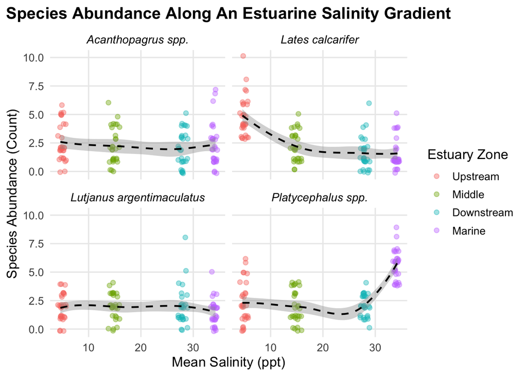

```r
#Order four zones spatially (from low salinity to high)
plot_data <- final_master_matrix %>%
  mutate(zone = factor(zone, levels = c("Upstream", "Middle", "Downstream", "Marine")))

#Build the multi-panel plot
ggplot(plot_data, aes(x = mean_salinity, y = count, color = zone)) +
  geom_jitter(alpha = 0.4, width = 0.5, height = 0.2) + #add jittered points so overlapping zeros at the bottom become visible
  geom_smooth(method = "loess", se = TRUE, color = "black", size = 0.8, linetype = "dashed") + # add a smoothed trend line to show the abundance trend across increasing salinity
  facet_wrap(~ scientific_name, scales = "fixed") + # Create a panel for each species
  theme_minimal(base_size = 13) +
  labs(
    x = "Mean Salinity (ppt)", #x-axis title
    y = "Species Abundance (Count)", #y-axis title
    title = "Species Abundance Along An Estuarine Salinity Gradient", #plot title
    color = "Estuary Zone" # colour by estuary zone (using levels as defined before)
  ) +
  theme(
    strip.text = element_text(face = "italic", size = 11, color = "black"),  #using element_text(face = "italic") to italicise scientific names
    legend.position = "right", #legend on the right of the plot
    panel.grid.minor = element_blank(),
    plot.title = element_text(face = "bold", hjust = 0.5),
    plot.subtitle = element_text(hjust = 0.5, color = "grey40")
  )
```